# IEME4200 Human Centered Design & Innovation (Fall 2022)

Welcome to my Jupyter Markdown for IEME 4200! The goal of this course is to provide an introduction to human-centered design, theory, and practices, as well as hands-on experience creating a product. Each week's class will include a lecture/theory segment (Tuesday), and a lab on Thursday where we work on exercises to apply theory to practice.

## Introduction

The goal for this project was to create something to benefit mothers. Our team then set out to determine our goal and vision through conducting exploratory interviews with mothers, of whom were recruited from our networks.

From these interviews, we then discovered a common pain point with mothers experiencing hospital care truma due to negligent, non-empathetic care. In addition, we also spoke with an OBGYN medical professional, who emphasized a need for **more efficient, effective translation for mothers whose first language is not English / do not speak English.**

And thus, Lumo was born...

## Territory & Background

**Territory:**

- Regular hospital appointments / check-ups for minority, non-english speaking pregnant people
- Prenatal and postpartum care

**Background: Why it matters…**

- Significant health disparities have been associated with lack of English proficiency across a variety of health outcomes for pregnant women
- 1 out of 3 US hospitals fail to provide a translator for non-English speaking patients (despite the fact that providing such a service is federally required by law)
- 27.2% of women of colour (some of whom do not speak English) with low SES (Social Economic Status) reported any mistreatment versus 18.7% of white women with low SES

## Customers & Stakeholders

- **Non-English speaking minority mothers** receiving care in US hospitals
- **Healthcare professionals**: OBGYNs, Nurses, Medical interpreters

## Design Research & Documentation

**Interviews with mothers:**

- “I would have simple questions, but the doctors would have to call upon the interpreter and they would wait..I would just not ask them because I didn’t want to go through the process of calling an interpreter. I had spent enough time at the hospital”
- “I am a private person…I do not want any additional strangers in the room”
- "Sometimes I felt like I wasn’t taken seriously and my questions were brushed away after being translated”

**Interviews with healthcare providers:**

- “Interpretation currently significantly increases the time of an appointment”
- “Over the phone, body language and other cues are lost for both of us [mother and doctor] especially when I have to relay hard or upsetting information”

## Insights & Problem Articulation

Current efforts to bridge the language gap *take too much time*, *strip mothers of autonomy* and force them to be reliant on others, and *remove important emotional cues* such as body language from the conversation.

**Mothers and doctors need a solution that is more time efficient. Mothers want to feel autonomous and in control and both parties want to feel they are having a conversation.**

Patients feel there is a lack of compassionate communication between them and their doctor due to language barriers.

**There is an opportunity to bridge the language barrier between mothers who are non-english speakers and their healthcare providers during regular pregnancy check-ups.**

## Solution Ideas

**Live Progress Screen**

- A large screen in the hospital rooms where mothers can see the instructions from doctors or nurses immediately while giving birth, showing information such as contraction and baby progress.

**Emotion Communication (App)**

- A voice recognition app that picks up on a conversation and translates it into text. Mothers are able to express their emotions clearly by selecting emojis during the conversation.

**Undergraduate Pre-Medical Students as Certified Hospital Translators**

- A service that enables bilingual, undergraduate, female pre-med students to translate for and to mothers, pick up on emotional, cultural and vocal cues and communicate these nuances to the staff.

## First Protoypes

**Live Progress Screen**

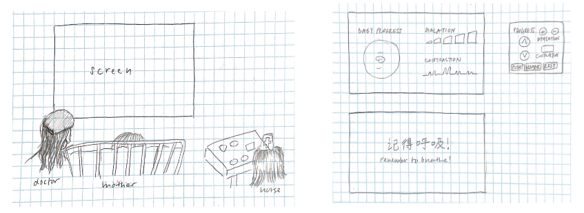

**Emotion Communication (App)**

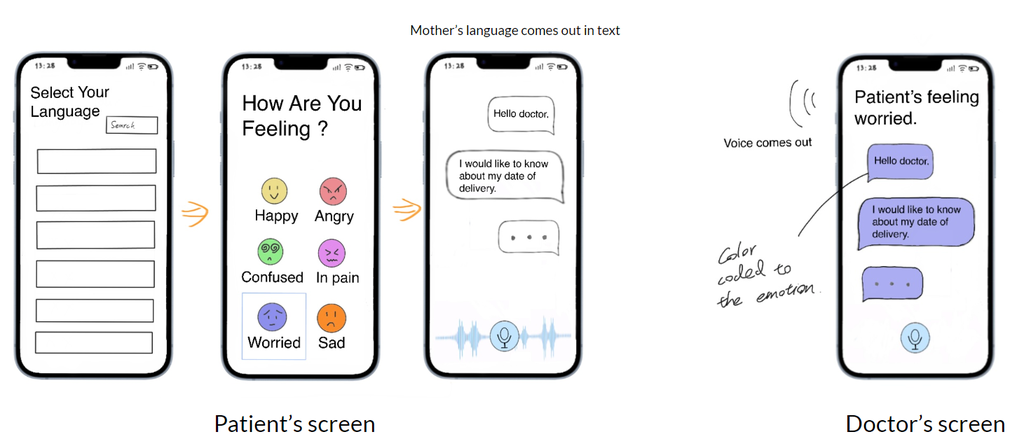

**Undergraduate Pre-Medical Students as Certified Hospital Translators**

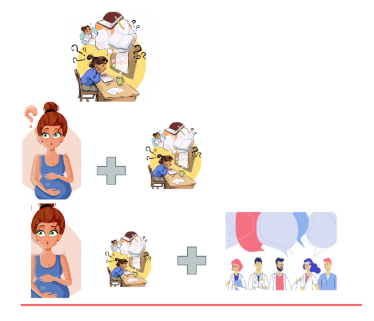

## Evaluation Customer Feedback

**Live Progress Screen**

- Mothers liked that the app automatically translates what the doctor says without an intermediary person
- “When the doctor says something, sometimes I would forget. Having that info visible, would be helpful”

**Emotion Communication (App)**

- “It would be nice if the app automatically translated what the doctor said”
- This gives back autonomy to the mothers; don’t need to rely on anyone else to communicate

**Undergraduate Pre-Medical Students as Certified Hospital Translators**

- Mothers believed it could be helpful, but felt a little uncomfortable with a stranger in the room
- This is baseline to what mothers are already receiving.
- “I have to wait for the interpreters to be called up whenever I want something translated”

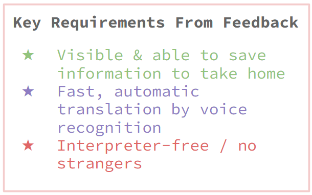

## Solution Iteration

We took the components of the Live Progress Screen and the Translation App that mothers found most helpful and used this feedback to drive the design of our final solution:

#### A Translating (tablet) App that pairs with Google Pixel Earbuds and has a live transcription.

Features:

- Aids in autonomous translation during check-ups pre and post birth
- Harnesses existing universal translating software & existing earbud tech (voice recognition, hands free)
- Implemented with large screen for patient and doctor look at together
- Bookmarking feature that allows mothers to save helpful comments from the discussion between mother & doctor
- Creates an efficient experience and a more intimate, private conversation

### LUMO: A Logical story / The Solution in its Context

First, mothers and doctors use **pixel bud earpieces**, which pick up their words as they speak in their native languages. Along with the earpieces, the mothers and doctors also have an ipad in front of them. The mothers use to select their language on the ipad and both parties speak out loud to each other. As they do so, they read a live translation on the ipad of what the other has said and respond in real time.

The live translation allows a mother to easily scroll up through the transcription. She gets to bookmark phrases, questions or pieces of information she would like to review at any point during the appointment or save and review later on. She won’t need to worry about forgetting anything important, and will be able to review the conversation at her convenience in her own language. With the consent of mothers and doctors, the mothers will be able to take home a printed or digital copy of her bookmarks.

## How to Implement Solution

1. Incorporate [app](https://www.figma.com/proto/u36ZD4vPvIeuyycDGgbgHn/Prototype?node-id=103-41&scaling=scale-down&page-id=0%3A1&starting-point-node-id=103%3A41&show-proto-sidebar=1&t=XHuh8L4334pTWQJH-1&mode=design) onto hospital tablets
2. Allow mother to direct use of the app
3. Save or discard transcript after session

[figure not shown]

## Solution compared to Competition

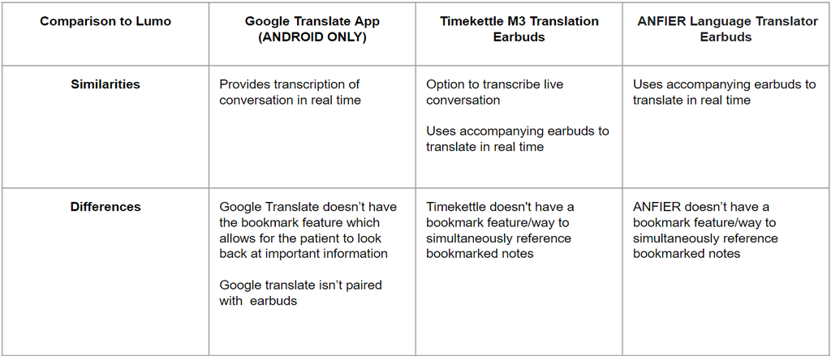

While LUMO shares the basic functionality of live translation as some of its competitors, LUMO’s **bookmarking and transcription** feature allows for a heightened user autonomy and a sense of reliability that other competitors are lacking in.

## Proposed Overall Experience

Below is a Journey Map for a User:

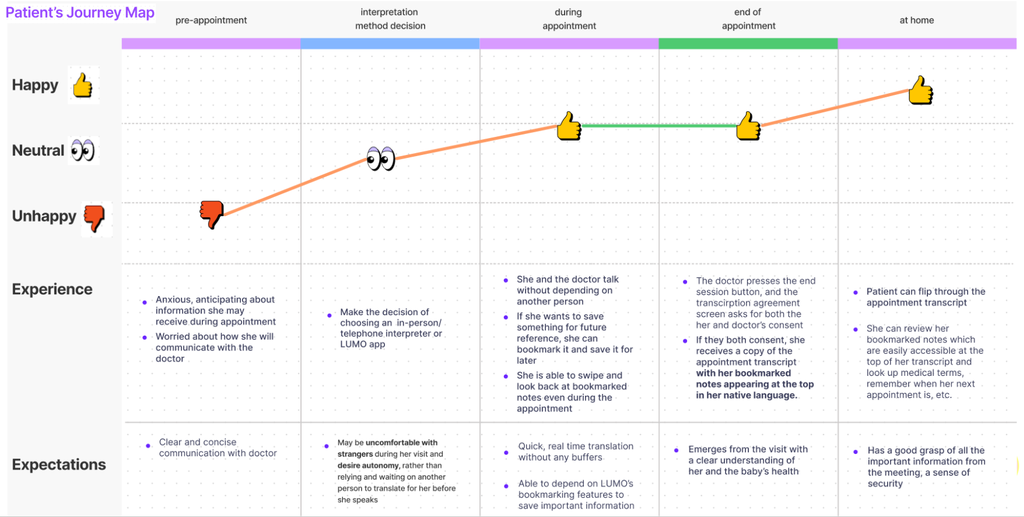

## Final Pitch Video

[Link](https://youtu.be/TUtkYGcVBCk)